# index

## Introduction

Since the emergence of Bitcoin in 2009, various digital currencies have begun to emerge. This type of currency, which was originally created to resist the abuse of currency and promote social fairness and efficiency, has many differences in the way of currency creation, storage, and circulation from the current global legal currency. From a social point of view. On the one hand, as an application of blockchain technology, digital currency has many good application scenarios. On the other hand, as a new thing, digital currency has many drawbacks, such as its anonymity, which is easily used by many elements for money laundering and other illegal and criminal funds and transaction.The low transparency of market information makes the price of digital currency easy to be manipulated and thus harm the interests of investors  
However, from the perspective of financial market research, the development of digital currency has become a brand new type of asset. Studying this emerging financial asset, which is very different from traditional assets, can help us understand the nature of financial transactions more deeply. In this project, three different types of RNN model are used to perform regression tasks to fit the prices of Bitcoin in the past few years.

### Research content of this report

The research in this report is about cryptocurrency price trend prediction based on GRU model. Cryptocurrency transactions are characterized by high frequency, high volatility and not limited by time and space. In traditional forecasting methods, the characteristics of cryptocurrencies themselves are not well preserved, and thus the forecasting accuracy is low and ineffective. Long-term and short-term memory networks (LSTM) and gated recurrent units (GRU) in deep learning can solve the long-term memory problem in cryptocurrency price prediction and improve the prediction effect. This report will use deep learning methods to predict the price trend of cryptocurrencies. The main contents are as follows.

1. This report is the first to apply the gated recurrent unit (GRU) model to predict the price trend of cryptocurrencies. The price of cryptocurrencies is preprocessed as the input of the neural network, and then the recurrent neural network (RNN), long and short-term memory network algorithm (LSTM) and GRU model are combined with deep learning to apply to cryptocurrency price trend prediction for experiments.
2. This report compares the experimental results of gated recurrent unit (GRU) for predicting bitcoin price trend with those of long short-term memory network (LSTM) and recurrent neural network (RNN), and the results show that the overall performance of gated recurrent unit (GRU) is more prominent and better than RNN and LSTM for prediction.

Related literatrue and contribution

Recurrent Neural Networks (RNN) and Long Term Short Term Memory (LSTM) advantages are favored over traditional Multi-Layer Perceptron (MLP) due to the temporal nature of the more advanced algorithms. Another form of RNN is the long-term short-term memory (LSTM) network, which differs from the Elman RNN in that, in addition to having memory, it can choose which data to remember and which to forget based on the weight and importance of that function. F.A. Gers et al. implemented an LSTM for a time series prediction task and found that the LSTM performed a time series prediction task with better results than RNN . Si W, Li J et al. combined recurrent neural networks with reinforcement learning methods to implement multi-objective stock index futures trading decisions . Guo T, Lin T et al. proposed an interpretable LSTM recurrent neural network, a multivariate LSTM that learns variable-specific representations, and experimentally demonstrated its performance . TORRES D G et al. analyzed the motivation behind applying a specific type of RNN to generate time series forecasts of volatile financial variables using multivariate correlated data. Recurrent neural networks (RNN), long and short-term memory models (LSTM), and gated recurrent units (GRU) have been widely used in forecasting research in various fields. Wenpeng Hu applied RNN, LSTM and GRU neural networks to predict stock index futures and used GRU neural networks to predict stock index prices with good results. Chengyuan Cao studied protein residue interaction prediction based on bidirectional recurrent neural networks. Lai, Ra, Chen, Ai Xiang et al. conducted a study on stock closing price prediction using GRU recurrent neural network, and this study showed that GRU model has strong generalization and learning ability and has high accuracy in predicting time series data. Shah and Zhang use Bayesian regression to predict the price change of Bitcoin. They used the 60-day historical change in bitcoin price to predict the future price. They also applied this model to a simple strategy for bitcoin trading. a. Greves et al. analyzed the bitcoin blockchain using support vector machine (SVM) and artificial neural network (ANN) to predict the price of bitcoin, using conventional ANN to predict the price direction with 55% accuracy, concluding that the predictability of blockchain data is limited. Zhou Mang , Gao Boy et al. conducted a study on short-term electric load prediction by GRU neural network, using multilayer GRU to construct a neural network with small prediction error and high accuracy. W.Q. Wang, H. Guo, Q.F. Fan used convolutional neural network (CNN) and GRU to predict the remaining life of an aero-engine. Jing-Yan Guo applied GRU method in LSTM model to predict the traffic flow in short time. The above studies show that LSTM and GRU models have better results in dealing with long time memory compared to RNN, and both LSTM and GRU have played a great role in prediction research in various fields and achieved better results. Although a large number of people have conducted prediction studies on cryptocurrencies in recent years, in terms of prediction performance, the use of deep learning techniques for deep learning techniques for this purpose is still in its early stages, and deep learning-based cryptocurrency forecasting still There is a lot of room for improvement. Moreover, in both traditional prediction models and RNNs, the long-range effects cannot be preserved, which reduces the performance of cryptocurrency prediction. The accuracy of cryptocurrency prediction is thus reduced.

Methodology

RNN models are developed for sequence data machine learning, and has been proved to be a successful model in related applications. RNN model started from simple-RNN nodes, and then got improved with LSTM nodes, recent years witnessed the application of GRU nodes.  
How would these 3 models perform in a task to fit a curve of Bitcoin prices? I have assumption that GRU is better than LSTM and LSTM is better than simple RNN. The assumption didn't come from random guess. An instiution formed from the history of RNN that the newer model beats the old one. Another reason is that I searched the internet and lots of work supported my assumption.  
Is it true or not? I built 3 models to explored the answer. 1.Basic recurrent neural network（RNN） A neural network is an artificial neural network that connects multiple single nodes together in a directed manner. And Recurrent Neural Network (RNN) is one of the neural network models, which has internal states that can demonstrate dynamic temporal behavior with both internal feedback connections and feedforward connections between processing unit nodes. It just so happens that many elements in the real world Many elements in the real world are interconnected, such as stock changes over time, etc. It is with recurrent neural networks (RNNs) having human-like memory capabilities that such prediction problems can be better solved.

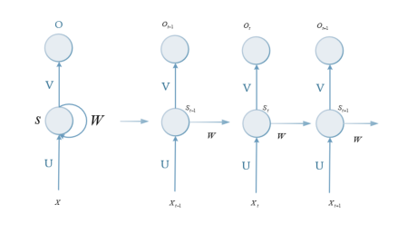

### Defects of the RNN model：

1. gradient vanishing problem ， gradient exploding problem
2. rnn uses more memory space than other cnn and full connections, and is more difficult to train 3.If tanh and relu are used as activation functions, it is impossible to handle too long sequences

2.Long and short-term memory network (LSTM) Recurrent neural networks have only state h in the hidden layer , and the responsiveness of state h is better in the short-term input, but it cannot keep the long-term state in the RNN, adding a state c to make it into another network model long short-term memory network (LSTM) .

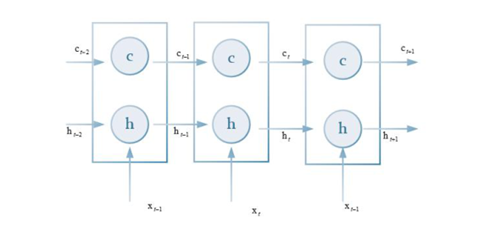

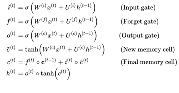

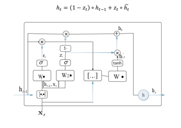

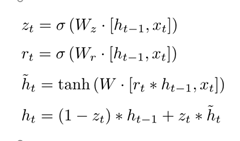

### Result analysis and conclusion

Model step:

RNN models are developed for sequence data machine learning, and has been proved to be a successful model in related applications. RNN model started from simple-RNN nodes, and then got improved with LSTM nodes, recent years witnessed the application of GRU nodes. How would these 3 models perform in a task to fit a curve of Bitcoin prices? I have assumption that GRU is better than LSTM and LSTM is better than simple RNN. The assumption didn't come from random guess. An instiution formed from the history of RNN that the newer model beats the old one. Another reason is that I searched the internet and lots of work supported my assumption.

Experimental results and analysis:

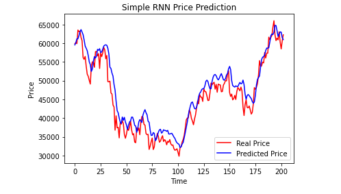

Mean squared error: 10405302.29

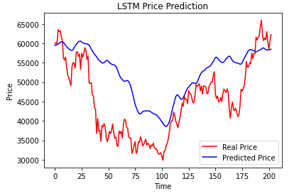

Mean squared error: 85684339.62

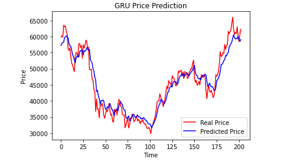

Mean squared error: 6891456.86

Conclusion

The simple RNN and GRU model show much better fitting curve than the LSTM, and GRU is also better than RNN from the MSE loss. This report mainly describes the experiments and results analysis of the deep learning based bitcoin price prediction model, firstly, we obtain the data, and then do the data processing and model training. The training results can be obtained that the deep learning based bitcoin price prediction achieves good results, especially the GRU model is much better than LSTM in terms of performance. The integration of LSTM or RNN with Wavelet can be applied to time series models in the future, which will be explored in future work. Also for the dataset, pruning using difficulty and hash rate variables can be considered based on the analysis of the model weights.

**References**

Elman J L. Finding structure in time[J]. Cognitive science, 1990, 14(2): 179-211. 胡文鹏. 基于神经网络的股指期货价格预测研究与应用[D]. 长沙：湖南大学，2018. 周莽, 高僮, 李晨光, et al. GRU 神经网络短期电力负荷预测研究[J]. 科技创新与应用, 2018, 253(33). 王文庆, 郭恒, 范启富. 基于 CNN 与 GRU 的航空发动机剩余寿命预测[C].第 37 届中国控制会议论文集（F）. 2018. 郭靖彦. 基于交通流量预测的车联网技术研究[D]. 成都：电子科技大学，2018. 梁秋, 王凡彬, 余龙秀, et al. 基于小波分析的比特币价格预测 [J]. 内江科技, 2015(5):129-130. Guo T, Lin T, Lu Y. An interpretable LSTM neural network for autoregressive exogenous model[J]. arXiv preprint arXiv:1804.05251, 2018. Gers F A, Eck D, Schmidhuber J. Applying LSTM to time series predictable through time-window approaches[M].Neural Nets WIRN Vietri-01. Springer, London, 2002: 193-200. Greaves A, Au B. Using the bitcoin transaction graph to predict the price of bitcoin[J]. No Data, 2015.